# Course Project - Practical Machine Learning

### Course Project - Practical Machine Learning

### Building a machine learning algorithm to predict activity quality from activity monitors.

Human Activity Recognition - **HAR** - has emerged as a key research area in the last years and is gaining increasing attention by the pervasive computing research community, especially for the development of context-aware systems. Further details can be found [here](http://groupware.les.inf.puc-rio.br/har).  
The data [they](http://groupware.les.inf.puc-rio.br/har) have provided was collected from accelerometers on the belt, forearm, arm, and dumbell of 6 participants. They were asked to perform barbell lifts correctly and incorrectly in 5 different ways.

```r
library(caret)
trainingData <- read.csv("~/Courses/Practical Machine Learning//pml-training.csv",
    na.strings = c("NA", ""))
testingData <- read.csv("~/Courses/Practical Machine Learning//pml-testing.csv")
```

The goal of this project is to predict the manner in which they did the exercise. The manner has been divided into following classes:

```r
levels(trainingData$classe)
```

```
## [1] "A" "B" "C" "D" "E"
```

### Cleaning and setting the data:

Removing columns with missing values:

```r
# trainingData <- trainingData[,!sapply(data,function(x) any(is.na(x)))]
trainingData <- trainingData[, which(colSums(is.na(trainingData)) == 0)]
```

Also, we remove any variables(columns) that doesn't seem relative(non-sensor data) to the prediction model:

```r
trainingData <- trainingData[, -grep("timestamp|X|user_name|new_window|num_window",
    names(trainingData))]
```

After removing the columns with missing values, we get following number of variables:

```r
names(trainingData)
```

```
##  [1] "roll_belt"            "pitch_belt"           "yaw_belt"
##  [4] "total_accel_belt"     "gyros_belt_x"         "gyros_belt_y"
##  [7] "gyros_belt_z"         "accel_belt_x"         "accel_belt_y"
## [10] "accel_belt_z"         "magnet_belt_x"        "magnet_belt_y"
## [13] "magnet_belt_z"        "roll_arm"             "pitch_arm"
## [16] "yaw_arm"              "total_accel_arm"      "gyros_arm_x"
## [19] "gyros_arm_y"          "gyros_arm_z"          "accel_arm_x"
## [22] "accel_arm_y"          "accel_arm_z"          "magnet_arm_x"
## [25] "magnet_arm_y"         "magnet_arm_z"         "roll_dumbbell"
## [28] "pitch_dumbbell"       "yaw_dumbbell"         "total_accel_dumbbell"
## [31] "gyros_dumbbell_x"     "gyros_dumbbell_y"     "gyros_dumbbell_z"
## [34] "accel_dumbbell_x"     "accel_dumbbell_y"     "accel_dumbbell_z"
## [37] "magnet_dumbbell_x"    "magnet_dumbbell_y"    "magnet_dumbbell_z"
## [40] "roll_forearm"         "pitch_forearm"        "yaw_forearm"
## [43] "total_accel_forearm"  "gyros_forearm_x"      "gyros_forearm_y"
## [46] "gyros_forearm_z"      "accel_forearm_x"      "accel_forearm_y"
## [49] "accel_forearm_z"      "magnet_forearm_x"     "magnet_forearm_y"
## [52] "magnet_forearm_z"     "classe"
```

The variable we are predicting is “**classe**”. Now, we partition the data into training set(70%) and cross-validation set(30%).

```r
set.seed(1)
inTrain <- createDataPartition(y = trainingData$classe, p = 0.7, list = FALSE)
training <- trainingData[inTrain, ]
cv <- trainingData[-inTrain, ]
```

Feature density plot:

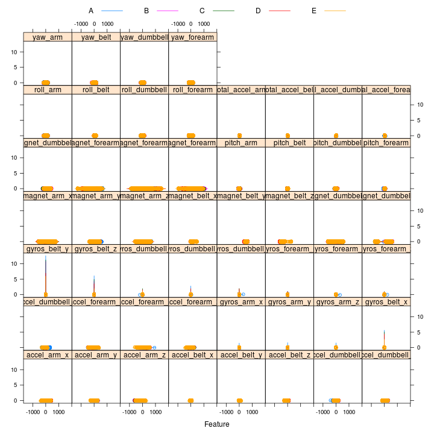

```r
featurePlot(x = training[, -53], y = training$classe, plot = "density", auto.key = list(columns = 5))
```

### Building the prediction model:

Rather than using the default training method(bootstrapping), we are using *cross-validation* method with 5 folds to train the data as it seems to be more efficient and fast.

```r
tctrl <- trainControl(method = "cv", number = 5)
modFit <- train(classe ~ ., data = training, method = "rf", trControl = tctrl)
```

Summary of our fitted model:

```r
modFit
```

[output not shown]

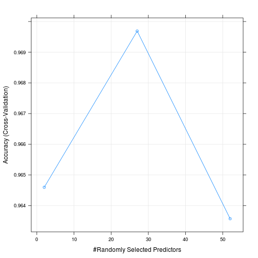

```r
plot(modFit)
```

### Prediction and errors:

As for the prediction statistics on cross-validation set:

```r
prediction <- predict(modFit, newdata = cv)
confusionMatrix(prediction, cv$classe)
```

```
## Confusion Matrix and Statistics
##
##           Reference
## Prediction    A    B    C    D    E
##          A 1660   21    0    0    0
##          B   10 1097   29    0    8
##          C    1   20  991   19    7
##          D    2    1    6  942    6
##          E    1    0    0    3 1061
##
## Overall Statistics
##
##                Accuracy : 0.977
##                  95% CI : (0.973, 0.981)
##     No Information Rate : 0.284
##     P-Value [Acc > NIR] : < 2e-16
##
##                   Kappa : 0.971
##  Mcnemar's Test P-Value : 0.000241
##
## Statistics by Class:
##
##                      Class: A Class: B Class: C Class: D Class: E
## Sensitivity             0.992    0.963    0.966    0.977    0.981
## Specificity             0.995    0.990    0.990    0.997    0.999
## Pos Pred Value          0.988    0.959    0.955    0.984    0.996
## Neg Pred Value          0.997    0.991    0.993    0.996    0.996
## Prevalence              0.284    0.194    0.174    0.164    0.184
## Detection Rate          0.282    0.186    0.168    0.160    0.180
## Detection Prevalence    0.286    0.194    0.176    0.163    0.181
## Balanced Accuracy       0.993    0.977    0.978    0.987    0.990
```

With an accuracy of 97.7%, our **out-of-sample error** is about **2.3 %**